# Exploring the BRFSS data

## Introduction

Hello Friend!

My name is Jake, I’m a research analyst from Canada! I’m an intern at a FinTech startup and use R nearly every day to clean data.

You might see some different functions than the one’s we learned in our course - I’ll leave comments so you know what’s going on! :)

## Setup

### Load packages

```r
library(tidyverse)
library(lubridate)
library(scales)
library(DT)
theme_set(theme_light())
```

### Load data

```r
load(here::here("data/_384b2d9eda4b29131fb681b243a7767d_brfss2013.Rdata"))
```

## About The Data

*Describe how the observations in the sample are collected, and the implications of this data collection method on the scope of inference (generalizability / causality).*

The [BRFSS](https://www.cdc.gov/brfss/annual_data/2018/pdf/overview-2018-508.pdf) gathered their data using telephone calls in the form of interviews. Most states used a **disproportionate stratified sample (DSS)** design for their landline samples while Guam and Puerto Rico used a **simple random-sample design**.

In the DSS method, states controlled two strata: high-density and medium density.

*“…these were determined by the number of listed household numbers in its hundred block, or set of 100 telephone numbers with the same area code, prefix, and first 2 digits of the suffix and all possible combinations of the last 2 digits.”*

After calling in, the interviewers asked different amounts of questions depending on what state they were in.

The BRFSS questionnaire contained three parts:

1. The **core component** is a standard list of questions asked in every state so these columns contain national-level findings.
2. The **optional modules** are asked in states who elect to include them in their questionnaire - it is state-level across many states.
3. The **state-added questions** are untracked questions that were included by the state - they are state-level, but likely to be unique to the state who asked.

Due to this, only the core component could be generalized to the United States as the others will be region specific - *e.g., if we asked people in Hawaii if they thought the weather was nice in December, we wouldn’t assume everyone in the United States would think the same!*

The BFRSS also applies post-stratification weights to the data to re-balance their findings. This will be a caveat when analyzing and making assumptions with the data since it is not raw.

## Research Questions & EDA

### Question 1:

**Do people with higher average alcohol consumption use their seatbelt less?**

Drinking and driving don’t mix. So I’m wondering if people who drink more on average, are also more reckless. Let’s look at the `avedrnk2` and `seatbelt` variables and see if there’s correlation between those who drink more on average and those who do not always wear a seatbelt when driving.

**Hypothesis:**

If alcohol consumption *increases*, then the proportion of seatbelt usage should *decrease*.

```r
drinking_seatbelts <- brfss2013 %>%
  select(avedrnk2, seatbelt) %>% # grab our columns
  drop_na(avedrnk2, seatbelt) %>% # remove missing values
  mutate(seatbelt = ifelse( # split possible seatbelt responses into Always or Not Always
    seatbelt == "Always",
    "Always wear seatbelt",
    "Don't always wear seatbelt"),
    avedrnk2 = ifelse(
      avedrnk2 > 10,
      10,
      avedrnk2)) # make 10 the maximum number of average drinks

total_counts <- drinking_seatbelts %>%
  count(avedrnk2, name = "total") # to join with the data to calculate proportion

seatbelt_proportions <- drinking_seatbelts %>%
  count(avedrnk2, seatbelt) %>% # count drinks by seatbelt response
  inner_join(total_counts, by = "avedrnk2") %>% # add the total values
  mutate(proportion = n / total) # calculate proportion
```

We can confirm from our chart (below) that we have a non-linear, negative relationship where as one’s `average alcoholic drinks per day` increases, their likelihood to wear a `seatbelt` decreases!

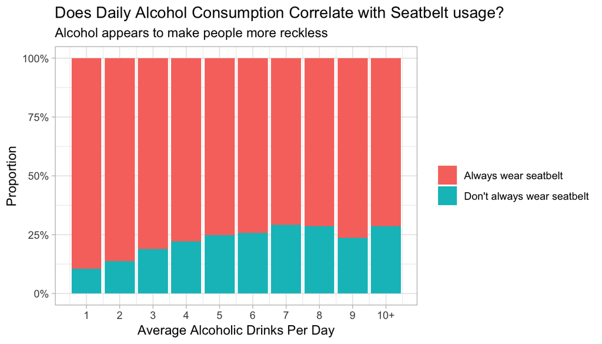

```r
seatbelt_proportions %>%
  ggplot(aes(x = avedrnk2, y = proportion, fill = seatbelt)) +
  geom_col(position = "fill") +
  scale_x_continuous(breaks = 0:10, labels = c(0:9, "10+")) +
  scale_y_continuous(labels = percent_format()) +
  labs(title = "Does Daily Alcohol Consumption Correlate with Seatbelt usage?",
       subtitle = "Alcohol appears to make people more reckless",
       x = "Average Alcoholic Drinks Per Day",
       y = "Proportion",
       fill = "")
```

**So should you be worried of these people when you’re on the road??**

Actually, ~8% people have five or more drinks a day and ~14% of people don’t wear always seatbelts…

… so what percentage of these people are driving around in the American population?

`P(A and B)`= `P(A)` × `P(B)`

```r
p_dont_always <- drinking_seatbelts %>%
  count(seatbelt, name = "subset_population") %>%
  mutate(total = sum(subset_population),
         proportion = subset_population / total) %>%
  filter(seatbelt == "Don't always wear seatbelt") %>%
  select(proportion)

p_avg_drinks_greater_5 <- drinking_seatbelts %>%
  count(avedrnk2, name = "subset_population") %>%
  mutate(total = sum(subset_population),
         proportion = subset_population / total) %>%
  filter(avedrnk2 >= 5) %>%
  summarize(total_prop = sum(proportion))
```

= `P(p_dont_always)` x `P(p_avg_drinks_greater_5)`

= 0.14262 x 0.0790131

Above is the probability of someone who consumes five or more drinks a day on average and is not wearing a seatbelt around you on the road. How safe does that make you feel?

|  | General Drinking Summary Statistics | Value |
| --- | --- | --- |
| 1 | average_avg_drinks | 2.12302319780494 |
| 2 | median_avg_drinks | 2 |
| 3 | sd | 1.68310515028593 |
| 4 | variance | 2.83284294691903 |
| 5 | IQR | 1 |
| 6 | min | 1 |
| 7 | max | 10 |

### Question 2:

**Does having children affect the average hours of sleep we get?**

Having a child must be exhasting; but I wouldn’t know that yet! I *am* curious if parenthood means less sleep, however. And I have a hunch it affects the mothers more than fathers.

**Hypothesis:**

If number of children *increases*, then the average hours of sleep will *decrease* for both men and women. Furthermore, the average hours of sleep will be *greater* for females than males

```r
# Which gender gets more sleep with kids?
gender_children_sleep <- brfss2013 %>%
  select(sex, children, sleptim1) %>%
  mutate(has_child_in_house = ifelse(children >= 3, 3, children)) %>%
  drop_na(sex, has_child_in_house, sleptim1)

total_counts <- gender_children_sleep %>%
  count(sex, has_child_in_house, name = "total")

children_proportions <- gender_children_sleep %>%
  count(sex, has_child_in_house, sleptim1) %>%
  inner_join(total_counts, by = c("sex", "has_child_in_house")) %>%
  mutate(proportion = n / total) %>%
  filter(sleptim1 <= 12)
```

Wow, look below! What a difference in the sleep distributions between people with no children and parents.

People with no children do not really follow a normal distribution with their sleep either. Interesting!

It’s also obvious from looking at the chart below that people with no children certainly get more their 8 hours far more often than parents.

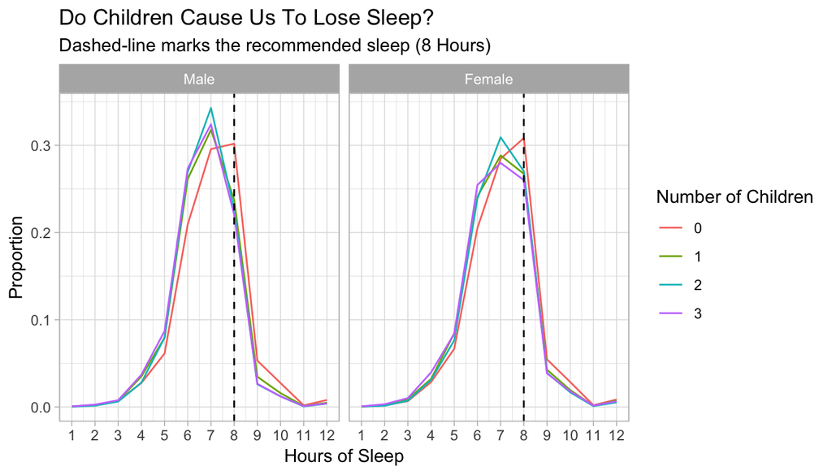

```r
children_proportions %>%
  ggplot(aes(x = sleptim1, y = proportion, colour = as.factor(has_child_in_house))) +
  geom_line() +
  facet_wrap(~sex) +
  geom_vline(xintercept = 8, linetype = 2) +
  scale_x_continuous(breaks = 0:12) +
  labs(title = "Do Children Cause Us To Lose Sleep?",
       subtitle = "Dashed-line marks the recommended sleep (8 Hours)",
       x = "Hours of Sleep",
       y = "Proportion",
       colour = "Number of Children")
```

Another observation in the chart above, the most common value for both genders who have no children is 8 hours of sleep, while those with more than one child are mostly getting 7 hours. You can say goodbye to that one hour of rest when rearing children.

And look below, the *Male’s* sleep appears to be the most impacted from a child! Curious - I had to double check the data on that one. I wonder why that is.

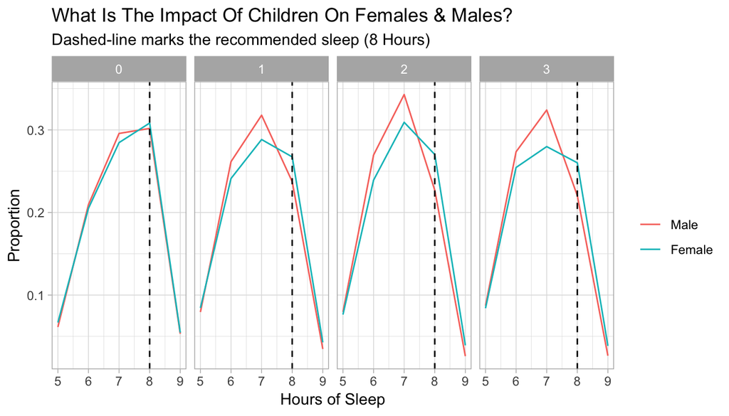

```r
children_proportions %>%
  filter(sleptim1 >= 5 & sleptim1 <= 9) %>%
  ggplot(aes(x = sleptim1, y=proportion, group = sex, colour = sex)) +
  geom_line() +
  facet_wrap(~has_child_in_house, ncol = 4) +
  geom_vline(xintercept = 8, linetype = 2) +
  labs(title = "What Is The Impact Of Children On Females & Males?",
       subtitle = "Dashed-line marks the recommended sleep (8 Hours)",
       x = "Hours of Sleep",
       y = "Proportion",
       colour = "")
```

### Summary Stats

#### Average Americans

Well, the mean and median sleep across Americans turns out to be 7 hours.

|  | Average American Sleeper Statistics | Value |
| --- | --- | --- |
| 1 | average_sleep | 7.05117422003795 |
| 2 | median_sleep | 7 |
| 3 | sd | 1.46573901823562 |
| 4 | variance | 2.14839086957833 |
| 5 | IQR | 2 |
| 6 | min | 1 |
| 7 | max | 24 |

#### Parents

Parents get a little less sleep.

|  | Parent Sleeping Statistics | Value |
| --- | --- | --- |
| 1 | average_sleep | 6.87017056692755 |
| 2 | median_sleep | 7 |
| 3 | sd | 1.41023401826292 |
| 4 | variance | 1.98875998626599 |
| 5 | IQR | 2 |
| 6 | min | 1 |
| 7 | max | 24 |

#### Non-parents

Non-parents get a bit more.

[output not shown]

### Question 3

The last question already? Well then, let’s look at poor mental health days in the past 30 days `menthlth` and see if weight is a dependent variable. I think that’d be interesting to explore by gender too.

**Hypothesis:**

If weight *deviates further from average weight* with respect to gender, then the number of poor mental health days will *increase.*

```r
# round weight into bins for easier analysis, cutting off at 500 lbs
sex_mental_health_weight <- brfss2013 %>%
  select(sex, menthlth, weight2, exeroft2) %>%
  drop_na() %>%
  mutate(weight2 = as.numeric(as.character(weight2)),
         bin = round(weight2, -1))  %>%
  filter(weight2 < 500)

# average mental health by bin and sex
binned_average_mental_health <- sex_mental_health_weight %>%
  group_by(bin, sex) %>%
  summarize(avg_mental_health_days = mean(menthlth))

# get rid of those with less than 100 observations
under_100_observations <- sex_mental_health_weight %>%
  count(bin, sex) %>%
  filter(n < 100)

# average weight by gender
average_weights_gender <- sex_mental_health_weight %>%
  group_by(sex) %>%
  summarize(average_weight = mean(weight2, na.rm = TRUE))
```

Fascinating.

I chose to use the y-axis and the fill gradient one variable to better present average poor mental health days.

- Short & dark bars represent lower mental health days on average.
- Tall & light bars represent higher mental health days on average.

I also present the average weight, calculated using `mean()`, to provide perspective to what is the most common weight for each gender.

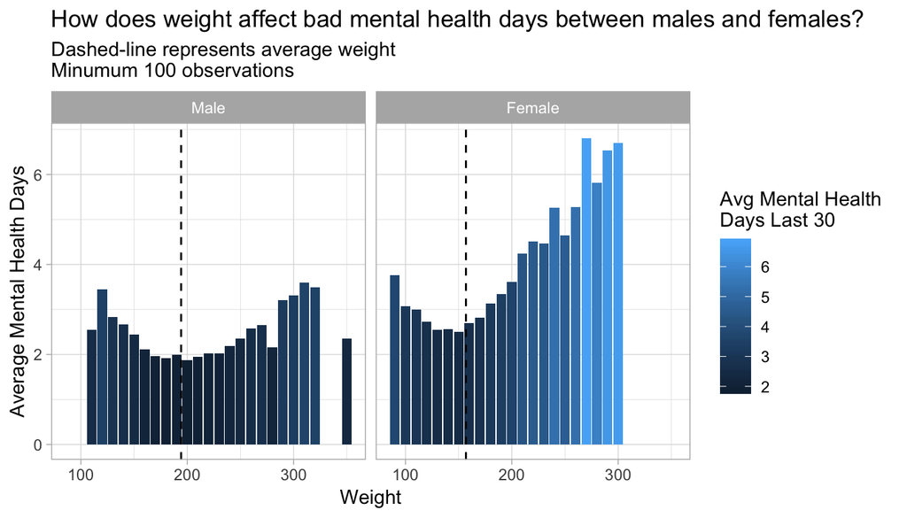

```r
binned_average_mental_health  %>%
  anti_join(under_100_observations) %>%
  ggplot(aes(x = bin, y = avg_mental_health_days, fill = avg_mental_health_days)) +
  geom_col() +
  geom_vline(data = average_weights_gender, mapping = aes(xintercept = average_weight), linetype = 2) +
  labs(title = "How does weight affect bad mental health days between males and females?",
       subtitle = "Dashed-line represents average weight\nMinumum 100 observations",
       fill = "Avg Mental Health \nDays Last 30",
       y = "Average Mental Health Days",
       x = "Weight") +
  facet_wrap(~sex)
```

Amazing. What I find interesting is the bi-modal distribution in the chart above - people who are very underweight and quite overweight compared to the average have more poor mental health days for both genders.

Of note, women are especially prone to poor mental health days when their weight begins exceeding 200 lbs.

Meanwhile, those who are the average weight are seemingly the happiest.

### Summary Stats

#### Males

|  | American Male Weight Statistics | Value |
| --- | --- | --- |
| 1 | average_weight | 194.210133626541 |
| 2 | median_weight | 190 |
| 3 | sd | 37.6861375955566 |
| 4 | variance | 1420.24496687122 |
| 5 | IQR | 45 |
| 6 | min | 50 |
| 7 | max | 496 |

#### Females

|  | American Female Weight Statistics | Value |
| --- | --- | --- |
| 1 | average_weight | 156.852087396234 |
| 2 | median_weight | 150 |
| 3 | sd | 35.9057127278978 |
| 4 | variance | 1289.22020649832 |
| 5 | IQR | 45 |
| 6 | min | 50 |
| 7 | max | 488 |

Thanks for reviewing my notebook! You’re awesome :)